# Lab 07 — t-tests and ANOVA

EAES 480 — Modern Statistics in Earth & Environmental Science

March 23, 2026

# Overview

This lab extends hypothesis testing from **claims about one mean** to:

- **one-sample t-tests**
- **two-sample t-tests**
- **paired t-tests**
- **ANOVA**

You will use the **US-AMS simplified AmeriFlux dataset** again and compare means across different time-based groups.

The core logic stays the same:

> estimate → uncertainty → test statistic → p-value

This lab emphasizes both **manual understanding** and **automated testing in R**.

# Learning goals

By the end of this lab, you should be able to:

- Compute and interpret a **one-sample t-test**
- Distinguish between **two-sample** and **paired** t-tests
- Compute and interpret **degrees of freedom**
- Explain the structure of an **ANOVA**
- Compare manual calculations to `t.test()` and `aov()`
- Use visualizations to support statistical interpretation
- Produce a fully reproducible R Markdown analysis

# Data

## Load and inspect

```r
# GOAL: Read the dataset and keep 2022–2023.

df <- read_csv("data/us-ams-simple.csv", na = c("-9999")) %>%
  clean_names() %>%
  filter(year_local %in% c(2022, 2023))

glimpse(df)
```

```
## Rows: 27,608
## Columns: 10
## $ year_local <dbl> 2022, 2022, 2022, 2022, 2022, 2022, 2022, 2022, 2022, 2022,…
## $ doy        <dbl> 144.4374, 144.4582, 144.4790, 144.4990, 144.5207, 144.5415,…
## $ daytime    <dbl> 1, 1, NA, NA, 1, 1, 1, 1, 1, 1, 1, 1, 1, 1, 1, 1, 1, 1, 1, …
## $ fc         <dbl> -15.06560, -12.75440, -21.22217, -16.41433, -20.21060, -16.…
## $ le         <dbl> 134.3940, 131.2010, 329.9336, 207.8460, 239.9890, 252.3480,…
## $ ta         <dbl> 16.46820, 16.50920, 25.25766, 18.08177, 18.83310, 18.90300,…
## $ reco       <dbl> 7.264363, 7.274225, 9.375862, 7.652758, 7.833698, 7.850531,…
## $ gpp        <dbl> 22.3299628, 20.0286255, 30.5980288, 24.0670918, 28.0442977,…
## $ swc        <dbl> 35.53763, 35.52599, 35.52599, 35.51435, 35.51435, 35.50659,…
## $ ts         <dbl> 13.58, 13.50, 13.49, 13.40, 13.40, 13.35, 13.30, 13.30, 13.…
```

## Derive time columns if needed

```r
# GOAL: Create date / month columns if they do not already exist.

df <- df %>%
  mutate(
    date = as.Date(floor(doy) - 1, origin = paste0(year_local, "-01-01")),
    month = month(date, label = TRUE, abbr = TRUE)
  )
```

# Part I — One-sample t-test

## 1) Choose a day and a variable

Select: - one **year** - one **numeric variable**

Examples: - `ta` - `swc` - `le` - `fc`

```r
target_year <- 2022
target_var  <- "ta"

sample_data <- df %>%
  filter(year_local == target_year) %>%
  slice_sample(n = 5000)

x <- sample_data[[target_var]]

mean(x, na.rm = TRUE); sd(x, na.rm = TRUE); length(x)
```

```
## [1] 16.49077
```

```
## [1] 10.76336
```

```
## [1] 5000
```

> What variable and day did you choose, and why? *I chose Air Temperature (ta) because I used the same variable in previous labs, and now I want to compare it with the 2022 data.*

## 2) State a null hypothesis

Write a claim about the mean of your chosen variable on that day.

Examples: - “The mean temperature on this day is 15 °C.” - “The mean latent heat flux on this day is 100 W m$^{-2}$.”

Fill in:

> $H_0$: $\mu = 11$

> $H_A$: $\mu \neq 11$

## 3) Compute the one-sample t-statistic manually

Use:

$t = (\bar{x} - \mu_0) / (s / \sqrt{n})$

```r
mu0 <- 11

xbar <- mean(x, na.rm = TRUE)
s <- sd(x, na.rm = TRUE)
n <- sum(!is.na(x))

t_stat <- (xbar - mu0) / (s / sqrt(n))
t_stat
```

```
## [1] 36.07197
```

## 4) Compute the p-value and degrees of freedom

```r
df_t <- n - 1

p_value <- 2 * pt(-abs(t_stat), df = df_t)

tibble(
  xbar = xbar,
  s = s,
  n = n,
  df_t = df_t,
  t_stat = t_stat,
  p_value = p_value
)
```

| xbar | s | n | df_t | t_stat | p_value |
| --- | --- | --- | --- | --- | --- |
| 16.49077 | 10.76336 | 5000 | 4999 | 36.07197 | 1.858076e-253 |

> What does the p-value suggest about your null hypothesis? *The p-value is extremely small, so I can reject the null hypothesis. This suggests that the true mean ta is statistically significantly different from my hypothesized value of 11.*

## 5) Compare with `t.test()`

```r
t.test(x, mu = mu0)
```

```
##
##  One Sample t-test
##
## data:  x
## t = 36.072, df = 4999, p-value < 2.2e-16
## alternative hypothesis: true mean is not equal to 11
## 95 percent confidence interval:
##  16.19235 16.78918
## sample estimates:
## mean of x
##  16.49077
```

> Does the `t.test()` output agree with your manual calculation? If not, why might that be? *Yes, they agree. The manual calculation and the automatic output both resulted in the same t-statistic and degrees of freedom.*

# Part II — Two-sample t-test

## 6) Compare the same variable across two day ranges

Choose: - the **same variable** - two different **day ranges in 2023**

```r
x1 <- df %>%
  filter(year_local == 2023, doy > 95 & doy < 97) %>%
  pull(target_var)

x2 <- df %>%
  filter(year_local == 2023, doy > 194 & doy < 196) %>%
  pull(target_var)

mean(x1, na.rm = TRUE); sd(x1, na.rm = TRUE); length(x1)
```

```
## [1] 11.64919
```

```
## [1] 7.542781
```

```
## [1] 95
```

```r
mean(x2, na.rm = TRUE); sd(x2, na.rm = TRUE); length(x2)
```

```
## [1] 24.43013
```

```
## [1] 4.667629
```

```
## [1] 95
```

> Why did you choose these two days? *To compare seasonal temperature differences between spring and summer, so I can see if there is a statistically significant shift.*

## 7) Summarize the difference in means

```r
xbar1 <- mean(x1, na.rm = TRUE)
xbar2 <- mean(x2, na.rm = TRUE)

s1 <- sd(x1, na.rm = TRUE)
s2 <- sd(x2, na.rm = TRUE)

n1 <- sum(!is.na(x1))
n2 <- sum(!is.na(x2))

mean_diff <- xbar1 - xbar2

tibble(
  xbar1 = xbar1,
  xbar2 = xbar2,
  mean_diff = mean_diff
)
```

| xbar1 | xbar2 | mean_diff |
| --- | --- | --- |
| 11.64919 | 24.43013 | -12.78095 |

## 8) Compute the two-sample t-statistic manually (Welch)

```r
se_diff <- sqrt((s1^2 / n1) + (s2^2 / n2))

t_stat <- mean_diff / se_diff

df_welch <- ((s1^2 / n1 + s2^2 / n2)^2) /
  (((s1^2 / n1)^2 / (n1 - 1)) + ((s2^2 / n2)^2 / (n2 - 1)))

p_value <- 2 * pt(-abs(t_stat), df = df_welch)

tibble(
  mean_diff = mean_diff,
  se_diff = se_diff,
  t_stat = t_stat,
  df_welch = df_welch,
  p_value = p_value
)
```

| mean_diff | se_diff | t_stat | df_welch | p_value |
| --- | --- | --- | --- | --- |
| -12.78095 | 0.9100625 | -14.04403 | 156.7855 | 1.58198e-29 |

> What does the sign of `mean_diff` mean? What does the p-value mean? *The negative sign means that the average spring temperature is lower than the average summer temperature. The extremely small p-value means that this difference is statistically significant.*

## 9) Compare with `t.test()`

```r
t.test(x1, x2)
```

```
##
##  Welch Two Sample t-test
##
## data:  x1 and x2
## t = -14.044, df = 156.79, p-value < 2.2e-16
## alternative hypothesis: true difference in means is not equal to 0
## 95 percent confidence interval:
##  -14.57851 -10.98338
## sample estimates:
## mean of x mean of y
##  11.64919  24.43013
```

> Does the automated t-test agree with your manual result? *Yes, they agree.*

## 10) Visualize the two groups

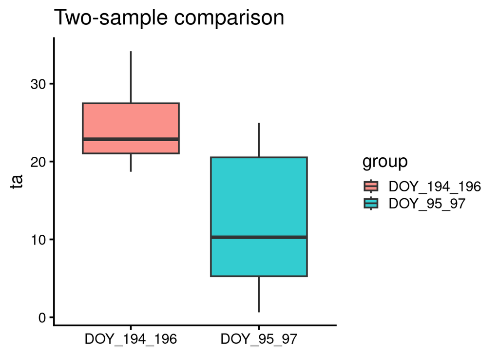

```r
day_range1 <- "95_97"
day_range2 <- "194_196"
plot_df <- bind_rows(
  tibble(group = paste0("DOY_", day_range1), value = x1),
  tibble(group = paste0("DOY_", day_range2), value = x2)
)

ggplot(plot_df, aes(x = group, y = value, fill = group)) +
  geom_boxplot(alpha = 0.8) +
  theme_classic(base_size = 18) +
  labs(
    x = NULL,
    y = target_var,
    title = "Two-sample comparison"
  )
```

> Does the plot match your statistical conclusion? *Yes. The boxplot shows that the summer box is higher on the y-axis than the spring box, with almost no overlap. This visual separation confirms the significant difference detected by the t-test.*

# Part III — Paired t-test

## 11) Compare the same days across two years

Choose one DOY and compare **2022 vs 2023** for the same variable.

```r
x1 <- df %>%
  filter(year_local == 2022, doy > 145 & doy < 165) %>%
  arrange(date) %>%
  pull(target_var)

x2 <- df %>%
  filter(year_local == 2023, doy > 145 & doy < 165) %>%
  arrange(date) %>%
  pull(target_var)

length(x1); length(x2)
```

```
## [1] 959
```

```
## [1] 959
```

> Why is this a paired comparison rather than an independent two-sample comparison? *It is paired because the observations are at the exact same time period measured across two different years.*

## 12) Compute paired differences manually

```r
d <- x1 - x2

dbar <- mean(d, na.rm = TRUE)
sd_d <- sd(d, na.rm = TRUE)
n <- sum(!is.na(d))

t_stat <- dbar / (sd_d / sqrt(n))
p_value <- 2 * pt(-abs(t_stat), df = n - 1)

tibble(
  dbar = dbar,
  sd_d = sd_d,
  n = n,
  t_stat = t_stat,
  p_value = p_value
)
```

| dbar | sd_d | n | t_stat | p_value |
| --- | --- | --- | --- | --- |
| 1.024384 | 5.187636 | 959 | 6.115087 | 1.403584e-09 |

> What does the sign of `dbar` mean? *This means that the ta on those specific days were slightly warmer on average in 2022 compared to 2023.*

## 13) Compare with `t.test(..., paired = TRUE)`

```r
t.test(x1, x2, paired = TRUE)
```

```
##
##  Paired t-test
##
## data:  x1 and x2
## t = 6.1151, df = 958, p-value = 1.404e-09
## alternative hypothesis: true mean difference is not equal to 0
## 95 percent confidence interval:
##  0.6956406 1.3531278
## sample estimates:
## mean difference
##        1.024384
```

> How does the paired t-test differ conceptually from the two-sample t-test? *An independent two-sample t-test compares the overall means of two completely unrelated groups. A paired t-test calculates the difference between paired observations.*

# Part IV — ANOVA

## 14) Create a categorical grouping variable

Group `ta` into broad seasonal categories:

- Summer
- Winter
- Other

```r
df_anova <- df %>%
  filter(!is.na(ta)) %>%
  mutate(
    month_group = case_when(
      month %in% c("Jun", "Jul", "Aug") ~ "Summer",
      month %in% c("Dec", "Jan", "Feb") ~ "Winter",
      TRUE ~ "Other"
    )
  )

df_anova %>% count(month_group)
```

| month_group | n |
| --- | --- |
| Other | 13582 |
| Summer | 8763 |
| Winter | 5263 |

## 15) Visualize the groups

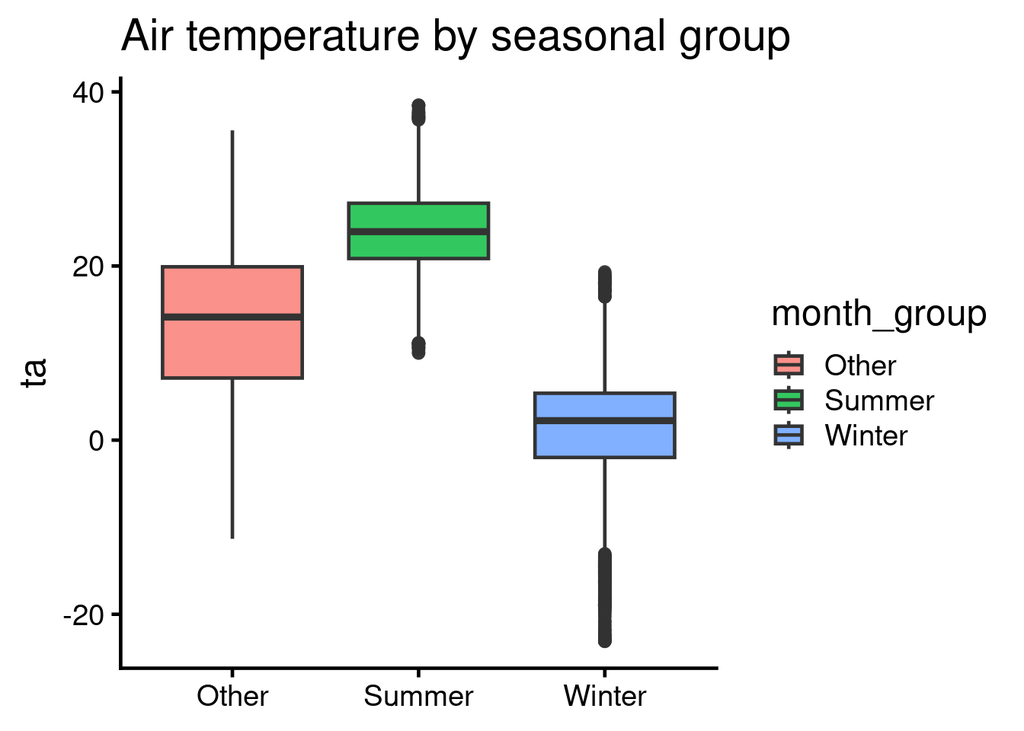

```r
ggplot(df_anova, aes(x = month_group, y = ta, fill = month_group)) +
  geom_boxplot(alpha = 0.8) +
  theme_classic(base_size = 18) +
  labs(
    x = NULL,
    y = "ta",
    title = "Air temperature by seasonal group"
  )
```

> Do the groups look different enough that ANOVA might detect a difference? *Yes. The boxplot enough separation between groups. Because the boxes do not overlap much, this implies the means are far enough apart for ANOVA to detect a difference.*

## 16) Compute ANOVA components manually

```r
grand_mean <- mean(df_anova$ta, na.rm = TRUE)

group_stats <- df_anova %>%
  group_by(month_group) %>%
  summarise(
    group_mean = mean(ta, na.rm = TRUE),
    n = n(),
    .groups = "drop"
  )

ss_between <- sum(group_stats$n * (group_stats$group_mean - grand_mean)^2)

df_anova2 <- df_anova %>%
  left_join(group_stats, by = "month_group")

ss_within <- sum((df_anova2$ta - df_anova2$group_mean)^2)

k <- n_distinct(df_anova$month_group)
n_total <- nrow(df_anova)

df_between <- k - 1
df_within <- n_total - k

ms_between <- ss_between / df_between
ms_within <- ss_within / df_within

f_stat <- ms_between / ms_within
p_value <- pf(f_stat, df1 = df_between, df2 = df_within, lower.tail = FALSE)

tibble(
  grand_mean = grand_mean,
  ss_between = ss_between,
  ss_within = ss_within,
  df_between = df_between,
  df_within = df_within,
  f_stat = f_stat,
  p_value = p_value
)
```

| grand_mean | ss_between | ss_within | df_between | df_within | f_stat | p_value |
| --- | --- | --- | --- | --- | --- | --- |
| 14.51412 | 1704462 | 1420623 | 2 | 27605 | 16560.23 | 0 |

> In your own words, what do `ss_between` and `ss_within` represent? *ss_between: Represents the variation between the different groups.* *ss_within: Represents the normal variation within each group.*

## 17) Compare with `aov()`

```r
model <- aov(ta ~ month_group, data = df_anova)
summary(model)
```

```
##                Df  Sum Sq Mean Sq F value Pr(>F)
## month_group     2 1704462  852231   16560 <2e-16 ***
## Residuals   27605 1420623      51
## ---
## Signif. codes:  0 '***' 0.001 '**' 0.01 '*' 0.05 '.' 0.1 ' ' 1
```

> What does the ANOVA p-value tell you? Does it tell you which groups differ? *This p-value tells me that at least one of the seasonal group mean is significantly different from the others.*

## 18) Final reflection

Answer in **5–7 sentences**:

- How is a one-sample t-test different from a two-sample t-test?
- Why is a paired t-test special?
- How is ANOVA a generalization of the t-test?
- What stayed the same across all these tests?

> *A one-sample t-test compares a single group mean to a hypothesized value, whereas a two-sample t-test compares the means of two entirely independent groups. A paired t-test is unique because it analyzes dependent data. ANOVA serves as a generalization of the t-test, allowing us to compare means across three or more groups simultaneously without inflating our error rate. The logic stayed the exact same across all these tests by calculating a test statistic and then comparing the estimated effect size against the data uncertainty.*

# Submission

- Knit your `.Rmd` to HTML.
- Commit and push both the `.Rmd` and knitted `.html` to your GitHub repo.
- Submit the GitHub repository link on Canvas.